# 市场观察

## D、择时

### (d1)等权指数

从历史来看，A股市场存在小盘股效应，市值小的股票长期整体跑赢大市值的股票，美股市场同样存在类似的现象。而目前大部分指数的编制方案都是类似市值加权，为了抛去市值的影响，下面展示几个等权指数，其中中证500等权和沪深300等权是现有的指数，中证全指等权是自己编制的指数。等权指数可以视为一个更好地业绩比较基准。等权指数走势如下图：

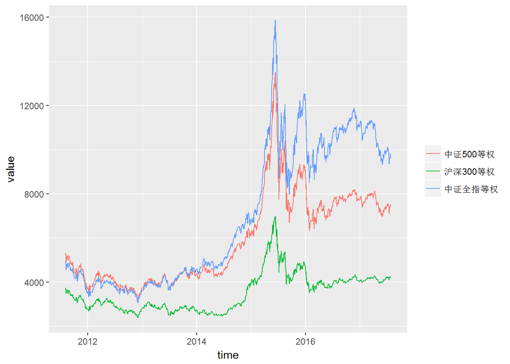

等权指数收益率统计见下表：

|  | 中证500等权 | 沪深300等权 | 中证全指等权 |
| --- | --- | --- | --- |
| 2011-08-02 ~ 2011-12-30 | -29.2% | -25.5% | -27.8% |
| 2012-01-04 ~ 2012-12-31 | -0.0% | 1.5% | 2.2% |
| 2013-01-04 ~ 2013-12-31 | 16.7% | -3.2% | 25.8% |
| 2014-01-02 ~ 2014-12-31 | 40.2% | 43.7% | 46.0% |
| 2015-01-05 ~ 2015-12-31 | 47.6% | 20.1% | 84.4% |
| 2016-01-04 ~ 2016-12-30 | -15.1% | -15.1% | -10.3% |
| 2017-01-03 ~ 2017-07-28 | -2.3% | 5.4% | -11.5% |
| 累计收益率 | 41.8% | 13.2% | 98.6% |
| 年化收益率 | 6.0% | 2.1% | 12.1% |
| 年化波动率 | 28.2% | 25.5% | 28.6% |
| 年化Sharpe值 | 21.2% | 8.2% | 42.3% |
| 最大回撤 | 53.3% | 50.0% | 49.7% |

### (d2)大盘均线强弱指数

大盘均线强弱指数在一定程度上可以视为一个反转指标，当大盘均线得分接近8分时，预示市场接近顶部，当大盘均线得分接近0分时，预示市场接近底部。  
大盘均线强弱指数近一年来走势如下图：

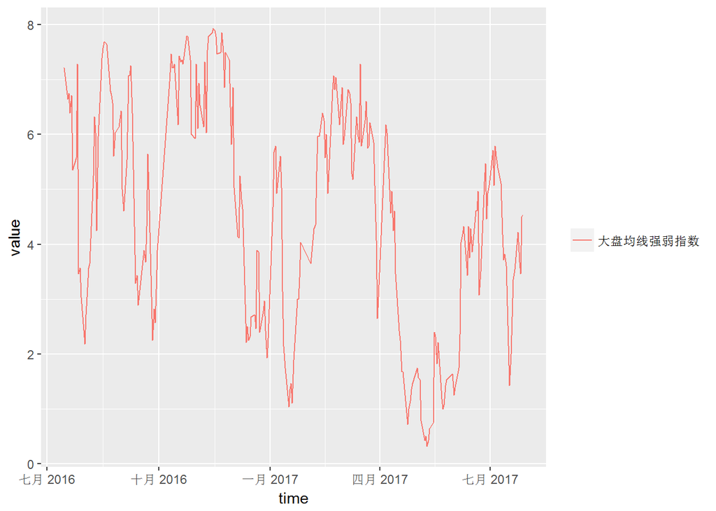

申万一级行业的最新得分见下表：

| 日期 | 指数代码 | 行业 | 最新得分 | 上周得分 |
| --- | --- | --- | --- | --- |
| 2017-07-28 | EI801040 | 钢铁 | 8 | 8 |
| 2017-07-28 | EI801050 | 有色金属 | 8 | 8 |
| 2017-07-28 | EI801080 | 电子 | 8 | 7 |
| 2017-07-28 | EI801120 | 食品饮料 | 8 | 8 |
| 2017-07-28 | EI801170 | 交通运输 | 8 | 8 |
| 2017-07-28 | EI801780 | 银行 | 8 | 8 |
| 2017-07-28 | EI801020 | 采掘 | 7 | 8 |
| 2017-07-28 | EI801030 | 化工 | 6 | 6 |
| 2017-07-28 | EI801180 | 房地产 | 6 | 6 |
| 2017-07-28 | EI801710 | 建筑材料 | 6 | 8 |
| 2017-07-28 | EI801790 | 非银金融 | 6 | 8 |
| 2017-07-28 | EI801200 | 商业贸易 | 5 | 3 |
| 2017-07-28 | EI801230 | 综合 | 5 | 2 |
| 2017-07-28 | EI801730 | 电气设备 | 5 | 1 |
| 2017-07-28 | EI801110 | 家用电器 | 4 | 8 |
| 2017-07-28 | EI801140 | 轻工制造 | 4 | 3 |
| 2017-07-28 | EI801720 | 建筑装饰 | 4 | 7 |
| 2017-07-28 | EI801740 | 国防军工 | 3 | 5 |
| 2017-07-28 | EI801010 | 农林牧渔 | 2 | 1 |
| 2017-07-28 | EI801130 | 纺织服装 | 2 | 1 |
| 2017-07-28 | EI801160 | 公用事业 | 2 | 1 |
| 2017-07-28 | EI801210 | 休闲服务 | 2 | 0 |
| 2017-07-28 | EI801750 | 计算机 | 2 | 0 |
| 2017-07-28 | EI801760 | 传媒 | 2 | 0 |
| 2017-07-28 | EI801770 | 通信 | 2 | 0 |
| 2017-07-28 | EI801890 | 机械设备 | 2 | 1 |
| 2017-07-28 | EI801150 | 医药生物 | 1 | 0 |
| 2017-07-28 | EI801880 | 汽车 | 1 | 2 |

### (d3)LLT及均线择时

LLT本质上是一个改进的单均线择时指标，较原始的均线择时延迟更低。  
择时模型和指数本身的净值走势如下图：

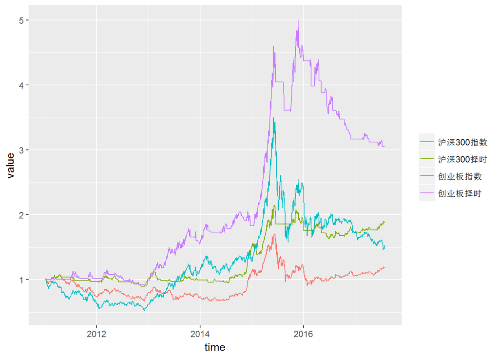

择时模型和指数的收益率统计如下表：

|  | 沪深300指 | 沪深300LLT | 创业板指 | 创业板MA |
| --- | --- | --- | --- | --- |
| 2011-01-04 ~ 2011-12-30 | -25.0% | -2.5% | -35.9% | 1.9% |
| 2012-01-04 ~ 2012-12-31 | 7.6% | 5.4% | -2.1% | -1.7% |
| 2013-01-04 ~ 2013-12-31 | -7.6% | -3.2% | 82.7% | 55.7% |
| 2014-01-02 ~ 2014-12-31 | 51.7% | 52.4% | 12.8% | 17.7% |
| 2015-01-05 ~ 2015-12-31 | 5.6% | 24.3% | 84.4% | 138.1% |
| 2016-01-04 ~ 2016-12-30 | -11.3% | -8.1% | -27.7% | -27.5% |
| 2017-01-03 ~ 2017-07-28 | 12.4% | 8.9% | -11.6% | -3.6% |
| 累计收益率 | 19.0% | 88.8% | 52.4% | 205.3% |
| 年化收益率 | 2.7% | 10.2% | 6.6% | 18.5% |
| 年化波动率 | 23.6% | 15.2% | 32.2% | 21.6% |
| 年化Sharpe值 | 11.3% | 66.8% | 20.5% | 85.7% |
| 最大回撤 | 46.7% | 24.0% | 58.4% | 39.0% |

择时模型最近10个交易日的信号如下表：

| 日期 | 沪深300收盘价 | 沪深300LLT | 沪深300择时信号 | 创业板收盘价 | 创业板MA30 | 创业板择时信号 |
| --- | --- | --- | --- | --- | --- | --- |
| 2017-07-17 | 3663.557 | 3638.844 | hold | 1656.433 | 1800.850 |  |
| 2017-07-18 | 3667.181 | 3643.249 | hold | 1667.488 | 1797.553 |  |
| 2017-07-19 | 3729.747 | 3649.546 | hold | 1684.771 | 1793.717 |  |
| 2017-07-20 | 3747.884 | 3658.114 | hold | 1688.610 | 1790.179 |  |
| 2017-07-21 | 3728.598 | 3666.179 | hold | 1690.145 | 1786.646 |  |
| 2017-07-24 | 3743.469 | 3673.657 | hold | 1686.439 | 1783.675 |  |
| 2017-07-25 | 3719.559 | 3680.426 | hold | 1688.095 | 1780.091 |  |
| 2017-07-26 | 3705.388 | 3685.576 | hold | 1681.310 | 1776.447 |  |
| 2017-07-27 | 3712.195 | 3690.182 | hold | 1742.191 | 1773.978 |  |
| 2017-07-28 | 3721.891 | 3695.048 | hold | 1734.074 | 1771.445 |  |

### (d4)网格交易

在经历了三轮股灾，A股逐步回归正常，在过去的一段时间呈现一个震荡的格局，如果未来没有增量信息，很可能维持震荡。结合股指期货的贴水，前期研究了一下网格交易。网格交易的结果如下图：

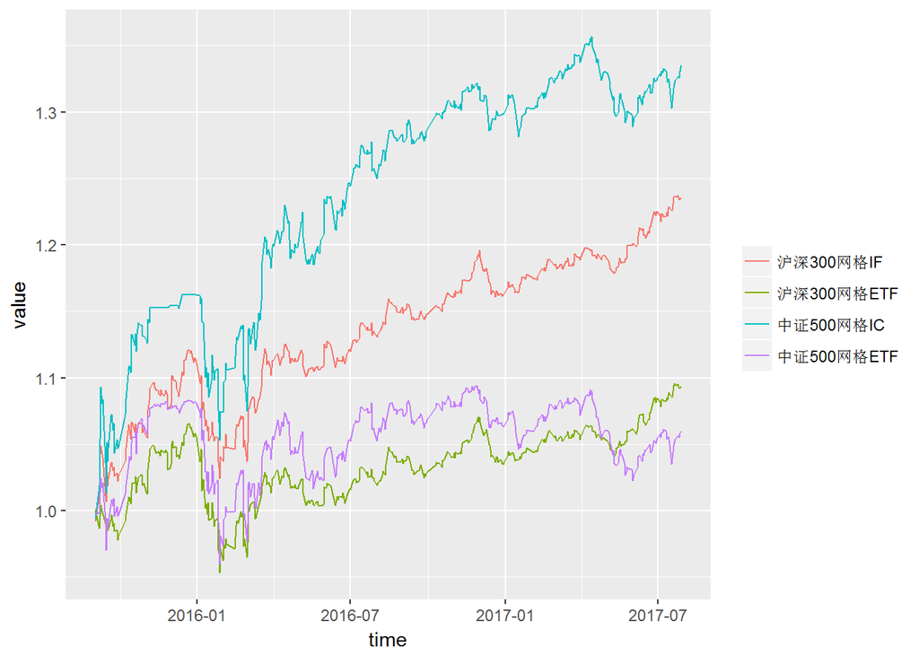

网格交易的收益统计如下表：

|  | 沪深300指数 | 沪深300网格IF | 沪深300网格ETF | 中证500指数 | 中证500网格IC | 中证500网格ETF |
| --- | --- | --- | --- | --- | --- | --- |
| 2015-09-02 ~ 2015-12-31 | 11.0% | 11.1% | 5.6% | 23.5% | 16.2% | 8.1% |
| 2016-01-04 ~ 2016-12-30 | -11.3% | 4.7% | -1.8% | -17.8% | 11.8% | -1.6% |
| 2017-01-03 ~ 2017-07-28 | 12.4% | 6.2% | 5.5% | -0.8% | 2.8% | -0.3% |
| 累计收益率 | 10.7% | 23.6% | 9.4% | 0.7% | 33.5% | 6.0% |
| 年化收益率 | 5.5% | 11.7% | 4.8% | 0.4% | 16.4% | 3.1% |
| 年化波动率 | 20.3% | 8.5% | 8.3% | 27.7% | 12.6% | 10.8% |
| 年化Sharpe值 | 26.9% | 138.1% | 57.7% | 1.4% | 130.3% | 28.7% |
| 最大回撤 | 26.4% | 8.6% | 10.5% | 33.5% | 9.4% | 11.4% |

## E、选股

### (e1)大小市值100

作为多因子选股的第一部分，有必要从市值因子说起。 下面利用总市值因子，在中证全指的成分股内，选出市值最大和最小的100只股票，这里剔除了ST、新上市、停牌和涨停的股票，等权配置，每月换仓一次，交易成本千分之三。观察历年来大、小市值组净值表现如下图。

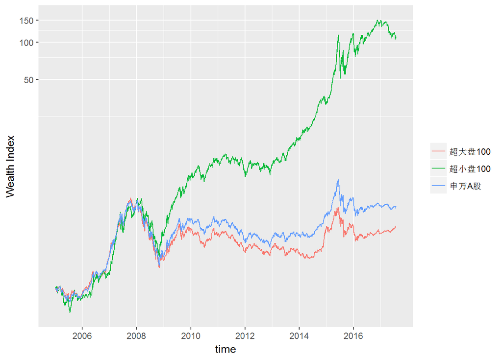

大小市值100的收益统计如下表：

|  | 超大盘100 | 超小盘100 | 申万A股 |
| --- | --- | --- | --- |
| 2005-01-05 ~ 2005-12-30 | -8.0% | -15.5% | -10.1% |
| 2006-01-04 ~ 2006-12-29 | 104.5% | 56.5% | 103.9% |
| 2007-01-04 ~ 2007-12-28 | 163.5% | 270.9% | 167.2% |
| 2008-01-02 ~ 2008-12-31 | -65.6% | -45.1% | -62.8% |
| 2009-01-05 ~ 2009-12-31 | 82.8% | 206.5% | 105.6% |
| 2010-01-04 ~ 2010-12-31 | -9.9% | 32.0% | -6.8% |
| 2011-01-04 ~ 2011-12-30 | -27.2% | -19.5% | -28.6% |
| 2012-01-04 ~ 2012-12-31 | 7.7% | 15.8% | 4.9% |
| 2013-01-04 ~ 2013-12-31 | -9.2% | 65.4% | 6.3% |
| 2014-01-02 ~ 2014-12-31 | 55.5% | 89.8% | 44.9% |
| 2015-01-05 ~ 2015-12-31 | 4.5% | 266.7% | 35.3% |
| 2016-01-04 ~ 2016-12-30 | -13.5% | 24.7% | -13.6% |
| 2017-01-03 ~ 2017-07-28 | 13.0% | -24.7% | -0.3% |
| 累计收益率 | 217.9% | 10882.7% | 369.2% |
| 年化收益率 | 9.6% | 45.3% | 13.1% |
| 年化波动率 | 28.8% | 35.6% | 28.4% |
| 年化Sharpe值 | 33.4% | 127.4% | 46.1% |
| 最大回撤 | 72.9% | 66.4% | 70.5% |

### (e2)银行股轮动

银行股轮动是参考集思录的热门贴银行股评级而来的，数据的提取和参数的设置和原贴有一定的差别，所以轮动的效果也会不太一样，不过回测的效果还不错，从现在开始跟踪。2013年以来银行股轮动的结果如下图：

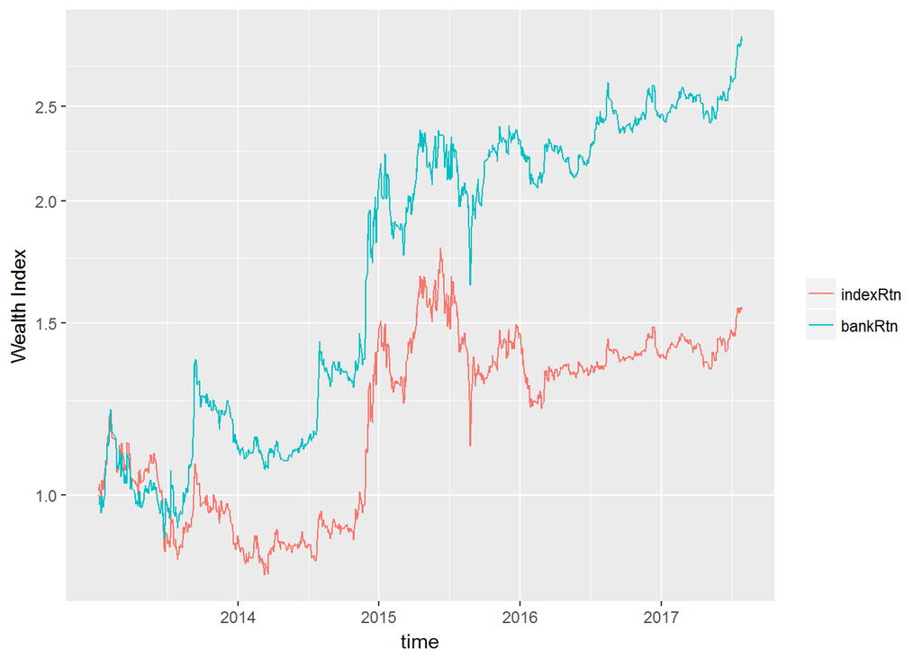

银行股轮动的收益统计如下表：

|  | 申万银行 | 银行股轮动 |
| --- | --- | --- |
| 2013-01-04 ~ 2013-12-31 | -9.2% | 12.5% |
| 2014-01-02 ~ 2014-12-31 | 63.2% | 87.6% |
| 2015-01-05 ~ 2015-12-31 | -1.4% | 9.4% |
| 2016-01-04 ~ 2016-12-30 | -4.9% | 6.2% |
| 2017-01-04 ~ 2017-07-28 | 11.8% | 19.0% |
| 累计收益率 | 55.3% | 192.1% |
| 年化收益率 | 10.1% | 26.4% |
| 年化波动率 | 27.4% | 29.3% |
| 年化Sharpe值 | 36.9% | 90.1% |
| 最大回撤 | 37.4% | 30.8% |

银行股轮动的最新得分如下表：

| 日期 | 代码 | 简称 | PB | ROE | 翻倍期 | 持仓 |
| --- | --- | --- | --- | --- | --- | --- |
| 2017-07-28 | EQ601818 | 光大银行 | 0.79 | 0.12 | 4.2 |  |
| 2017-07-28 | EQ601328 | 交通银行 | 0.76 | 0.10 | 4.2 | hold |
| 2017-07-28 | EQ600015 | 华夏银行 | 0.84 | 0.13 | 4.4 |  |
| 2017-07-28 | EQ601988 | 中国银行 | 0.81 | 0.11 | 4.5 |  |
| 2017-07-28 | EQ600016 | 民生银行 | 0.91 | 0.14 | 4.7 |  |
| 2017-07-28 | EQ601288 | 农业银行 | 0.92 | 0.14 | 4.8 |  |
| 2017-07-28 | EQ601998 | 中信银行 | 0.86 | 0.11 | 5.3 |  |
| 2017-07-28 | EQ601398 | 工商银行 | 1.00 | 0.14 | 5.4 |  |
| 2017-07-28 | EQ600000 | 浦发银行 | 1.03 | 0.14 | 5.5 |  |
| 2017-07-28 | EQ601166 | 兴业银行 | 1.06 | 0.14 | 5.7 |  |
| 2017-07-28 | EQ601939 | 建设银行 | 1.08 | 0.14 | 5.8 |  |
| 2017-07-28 | EQ000001 | 平安银行 | 0.91 | 0.11 | 5.8 |  |
| 2017-07-28 | EQ601169 | 北京银行 | 1.00 | 0.12 | 6.0 |  |
| 2017-07-28 | EQ601009 | 南京银行 | 1.09 | 0.13 | 6.2 |  |
| 2017-07-28 | EQ601997 | 贵阳银行 | 1.71 | 0.17 | 7.7 |  |
| 2017-07-28 | EQ600919 | 江苏银行 | 1.28 | 0.13 | 7.8 |  |
| 2017-07-28 | EQ002142 | 宁波银行 | 1.61 | 0.16 | 8.0 |  |
| 2017-07-28 | EQ600036 | 招商银行 | 1.62 | 0.15 | 8.3 |  |
| 2017-07-28 | EQ601229 | 上海银行 | 1.34 | 0.12 | 8.6 |  |
| 2017-07-28 | EQ600926 | 杭州银行 | 1.41 | 0.10 | 10.6 |  |
| 2017-07-28 | EQ601128 | 常熟银行 | 2.28 | 0.11 | 15.0 |  |
| 2017-07-28 | EQ600908 | 无锡银行 | 2.30 | 0.10 | 15.7 |  |
| 2017-07-28 | EQ603323 | 吴江银行 | 2.02 | 0.08 | 17.3 |  |
| 2017-07-28 | EQ002807 | 江阴银行 | 2.22 | 0.09 | 17.7 |  |
| 2017-07-28 | EQ002839 | 张家港行 | 3.35 | 0.09 | 23.1 |  |